# khyati_kaul_project

```python
# importing libraries
import os
import numpy as np
import pandas as pd
import matplotlib.pyplot as plt
import seaborn as sns
```

```python
 # defining the datasets
protein_old = pd.read_csv('protein_old.csv')
protein_new = pd.read_csv('protein_new.csv')
gdp = pd.read_csv('GDP_pc.csv')
concordance = pd.read_csv('countries_code.csv')
```

```python
print(protein_old.columns)
print(protein_new.columns)
print(gdp.columns)
print(concordance.columns)
```

```
Index(['Domain Code', 'Domain', 'Area Code (M49)', 'Area', 'Element Code',
       'Element', 'Item Code (FBS)', 'Item', 'Year Code', 'Year', 'Unit',
       'Value', 'Flag', 'Flag Description'],
      dtype='object')
Index(['Domain Code', 'Domain', 'Area Code (M49)', 'Area', 'Element Code',
       'Element', 'Item Code (FBS)', 'Item', 'Year Code', 'Year', 'Unit',
       'Value', 'Flag', 'Flag Description', 'Note'],
      dtype='object')
Index(['Country Name', 'Country Code', 'Indicator Name', 'Indicator Code',
       '1960', '1961', '1962', '1963', '1964', '1965', '1966', '1967', '1968',
       '1969', '1970', '1971', '1972', '1973', '1974', '1975', '1976', '1977',
       '1978', '1979', '1980', '1981', '1982', '1983', '1984', '1985', '1986',
       '1987', '1988', '1989', '1990', '1991', '1992', '1993', '1994', '1995',
       '1996', '1997', '1998', '1999', '2000', '2001', '2002', '2003', '2004',
       '2005', '2006', '2007', '2008', '2009', '2010', '2011', '2012', '2013',
       '2014', '2015', '2016', '2017', '2018', '2019', '2020', '2021', '2022',
       '2023'],
      dtype='object')
Index(['Country Code', 'Country', 'M49 Code', 'ISO2 Code', 'ISO3 Code',
       'Start Year', 'End Year'],
      dtype='object')
```

```python
gdp
```

|  | Country Name | Country Code | Indicator Name | Indicator Code | 1960 | 1961 | 1962 | 1963 | 1964 | 1965 | ... | 2014 | 2015 | 2016 | 2017 | 2018 | 2019 | 2020 | 2021 | 2022 | 2023 |
| --- | --- | --- | --- | --- | --- | --- | --- | --- | --- | --- | --- | --- | --- | --- | --- | --- | --- | --- | --- | --- | --- |
| 0 | Aruba | ABW | GDP per capita (current US$) | NY.GDP.PCAP.CD | NaN | NaN | NaN | NaN | NaN | NaN | ... | 26129.839060 | 27458.225330 | 27441.529660 | 28440.051960 | 30082.127640 | 31096.205070 | 22855.932320 | 27200.061080 | 30559.533530 | 33984.790620 |
| 1 | Africa Eastern and Southern | AFE | GDP per capita (current US$) | NY.GDP.PCAP.CD | 186.132432 | 186.947182 | 197.408105 | 225.447007 | 209.005786 | 226.883067 | ... | 1656.107642 | 1479.564123 | 1329.777824 | 1520.171298 | 1538.924188 | 1493.780445 | 1344.080962 | 1522.590088 | 1628.024526 | 1659.515290 |
| 2 | Afghanistan | AFG | GDP per capita (current US$) | NY.GDP.PCAP.CD | NaN | NaN | NaN | NaN | NaN | NaN | ... | 625.054942 | 565.569730 | 522.082216 | 525.469771 | 491.337221 | 496.602504 | 510.787063 | 356.496214 | 357.261153 | 415.707417 |
| 3 | Africa Western and Central | AFW | GDP per capita (current US$) | NY.GDP.PCAP.CD | 121.938353 | 127.452629 | 133.825452 | 139.006714 | 148.547736 | 155.563837 | ... | 2204.995700 | 1845.767804 | 1616.843198 | 1560.162999 | 1703.896392 | 1783.654365 | 1664.249176 | 1747.840549 | 1777.235012 | 1568.724310 |
| 4 | Angola | AGO | GDP per capita (current US$) | NY.GDP.PCAP.CD | NaN | NaN | NaN | NaN | NaN | NaN | ... | 5005.999741 | 3213.902611 | 1807.952941 | 2437.259712 | 2538.591391 | 2189.855714 | 1449.922867 | 1925.874661 | 2929.694455 | 2308.159767 |
| ... | ... | ... | ... | ... | ... | ... | ... | ... | ... | ... | ... | ... | ... | ... | ... | ... | ... | ... | ... | ... | ... |
| 261 | Kosovo | XKX | GDP per capita (current US$) | NY.GDP.PCAP.CD | NaN | NaN | NaN | NaN | NaN | NaN | ... | 3902.494244 | 3520.628507 | 3759.449591 | 4009.317993 | 4384.186241 | 4415.997161 | 4310.888247 | 5270.426702 | 5290.947472 | 5960.158205 |
| 262 | Yemen, Rep. | YEM | GDP per capita (current US$) | NY.GDP.PCAP.CD | NaN | NaN | NaN | NaN | NaN | NaN | ... | 1430.164210 | 1362.173794 | 975.359407 | 811.165964 | 633.887206 | 623.376165 | 559.564673 | 522.173513 | 615.702079 | 477.409029 |
| 263 | South Africa | ZAF | GDP per capita (current US$) | NY.GDP.PCAP.CD | 532.147504 | 545.657512 | 563.423009 | 604.536855 | 645.873376 | 684.621228 | ... | 6856.731371 | 6112.273825 | 5651.205852 | 6618.335083 | 6914.178032 | 6533.711210 | 5580.603831 | 6843.399419 | 6523.410978 | 6022.542542 |
| 264 | Zambia | ZMB | GDP per capita (current US$) | NY.GDP.PCAP.CD | 221.559849 | 209.693206 | 202.281031 | 203.219451 | 229.979246 | 287.425476 | ... | 1707.485731 | 1295.877887 | 1239.085279 | 1483.465773 | 1463.899979 | 1258.986198 | 951.644317 | 1127.160779 | 1447.123101 | 1330.727806 |
| 265 | Zimbabwe | ZWE | GDP per capita (current US$) | NY.GDP.PCAP.CD | 276.419762 | 279.016467 | 275.545586 | 277.005679 | 281.744516 | 294.145335 | ... | 1372.212781 | 1386.422847 | 1407.415364 | 3448.082537 | 2271.853335 | 1684.027904 | 1730.413489 | 1724.387731 | 2040.552459 | 2156.034004 |

266 rows × 68 columns

```python
gdp.columns = gdp.columns.str.replace(r'\[.*\]', '', regex=True)
```

```python
gdp.columns=gdp.columns.str.strip()
```

```python
gdp.columns
```

```
Index(['Country Name', 'Country Code', 'Indicator Name', 'Indicator Code',
       '1960', '1961', '1962', '1963', '1964', '1965', '1966', '1967', '1968',
       '1969', '1970', '1971', '1972', '1973', '1974', '1975', '1976', '1977',
       '1978', '1979', '1980', '1981', '1982', '1983', '1984', '1985', '1986',
       '1987', '1988', '1989', '1990', '1991', '1992', '1993', '1994', '1995',
       '1996', '1997', '1998', '1999', '2000', '2001', '2002', '2003', '2004',
       '2005', '2006', '2007', '2008', '2009', '2010', '2011', '2012', '2013',
       '2014', '2015', '2016', '2017', '2018', '2019', '2020', '2021', '2022',
       '2023'],
      dtype='object')
```

```python
gdp.columns=gdp.columns.str.lower()
```

```python
gdp.columns=gdp.columns.str.replace("","_")
```

```python
gdp.columns=gdp.columns.str.lower()
```

```python
gdp = gdp.replace("", np.nan, regex=True)
```

```python
gdp.dtypes
```

```
_c_o_u_n_t_r_y_ _n_a_m_e_         object
_c_o_u_n_t_r_y_ _c_o_d_e_         object
_i_n_d_i_c_a_t_o_r_ _n_a_m_e_     object
_i_n_d_i_c_a_t_o_r_ _c_o_d_e_     object
_1_9_6_0_                        float64
                                  ...
_2_0_1_9_                        float64
_2_0_2_0_                        float64
_2_0_2_1_                        float64
_2_0_2_2_                        float64
_2_0_2_3_                        float64
Length: 68, dtype: object
```

```python
gdp.columns = gdp.columns.str.replace("_", "").str.strip().str.lower().str.replace(" ", "_")
```

```python
gdp.columns = gdp.columns.str.strip()
```

```python
print(gdp.columns.tolist())
```

```
['country_name', 'country_code', 'indicator_name', 'indicator_code', '1960', '1961', '1962', '1963', '1964', '1965', '1966', '1967', '1968', '1969', '1970', '1971', '1972', '1973', '1974', '1975', '1976', '1977', '1978', '1979', '1980', '1981', '1982', '1983', '1984', '1985', '1986', '1987', '1988',…
```

```python
gdp = gdp.rename(columns={
    "Country Name": "country_name",
    "Country Code": "country_code",
    "Indicator Name": "indicator_name",
    "Indicator Code": "indicator_code"
})
```

```python
gdp_long = pd.melt(
    gdp,
    id_vars=["country_name", "country_code"],
    var_name="year",
    value_name="gdp"
)
```

```python
gdp_long[['country_name','country_code','year','gdp']]
```

|  | country_name | country_code | year | gdp |
| --- | --- | --- | --- | --- |
| 0 | Aruba | ABW | indicator_name | GDP per capita (current US$) |
| 1 | Africa Eastern and Southern | AFE | indicator_name | GDP per capita (current US$) |
| 2 | Afghanistan | AFG | indicator_name | GDP per capita (current US$) |
| 3 | Africa Western and Central | AFW | indicator_name | GDP per capita (current US$) |
| 4 | Angola | AGO | indicator_name | GDP per capita (current US$) |
| ... | ... | ... | ... | ... |
| 17551 | Kosovo | XKX | 2023 | 5960.158205 |
| 17552 | Yemen, Rep. | YEM | 2023 | 477.409029 |
| 17553 | South Africa | ZAF | 2023 | 6022.542542 |
| 17554 | Zambia | ZMB | 2023 | 1330.727806 |
| 17555 | Zimbabwe | ZWE | 2023 | 2156.034004 |

17556 rows × 4 columns

```python
print(gdp_long.head())
```

```
                  country_name country_code            year  \
0                        Aruba          ABW  indicator_name
1  Africa Eastern and Southern          AFE  indicator_name
2                  Afghanistan          AFG  indicator_name
3   Africa Western and Central          AFW  indicator_name
4                       Angola          AGO  indicator_name

                            gdp
0  GDP per capita (current US$)
1  GDP per capita (current US$)
2  GDP per capita (current US$)
3  GDP per capita (current US$)
4  GDP per capita (current US$)
```

```python
gdp_long = gdp_long[gdp_long['year'].str.isnumeric()]
gdp_long['year'] = gdp_long['year'].astype(int)
```

```python
gdp_long = gdp_long[gdp_long['year'] >= 1990]
```

```python
gdp_long['year']=gdp_long['year'].astype('Int64')
```

```python
gdp_long['gdp'] = gdp_long['gdp'].replace(['..', ''], np.nan)
```

```python
gdp_long['gdp'] = gdp_long['gdp'].astype('float64')
```

```python
gdp_long.dtypes
```

```
country_name     object
country_code     object
year              Int64
gdp             float64
dtype: object
```

```python
gdp_long.describe()
```

|  | year | gdp |
| --- | --- | --- |
| count | 9044.0 | 8632.000000 |
| mean | 2006.5 | 12374.288833 |
| std | 9.811251 | 20748.471498 |
| min | 1990.0 | 22.952133 |
| 25% | 1998.0 | 1148.509292 |
| 50% | 2006.5 | 3834.097830 |
| 75% | 2015.0 | 14821.331417 |
| max | 2023.0 | 256580.515100 |

```python
gdp_long
```

|  | country_name | country_code | year | gdp |
| --- | --- | --- | --- | --- |
| 8512 | Aruba | ABW | 1990 | 12187.536360 |
| 8513 | Africa Eastern and Southern | AFE | 1990 | 822.817638 |
| 8514 | Afghanistan | AFG | 1990 | NaN |
| 8515 | Africa Western and Central | AFW | 1990 | 590.321438 |
| 8516 | Angola | AGO | 1990 | 965.866840 |
| ... | ... | ... | ... | ... |
| 17551 | Kosovo | XKX | 2023 | 5960.158205 |
| 17552 | Yemen, Rep. | YEM | 2023 | 477.409029 |
| 17553 | South Africa | ZAF | 2023 | 6022.542542 |
| 17554 | Zambia | ZMB | 2023 | 1330.727806 |
| 17555 | Zimbabwe | ZWE | 2023 | 2156.034004 |

9044 rows × 4 columns

WE HAVE CLEANED THE GDP DATASET AND CONVERTED IT INTO LONG FORMAT SUITABLE FOR MERGING WITH CONCORDANCE FILE.

```python
protein_old
```

|  | Domain Code | Domain | Area Code (M49) | Area | Element Code | Element | Item Code (FBS) | Item | Year Code | Year | Unit | Value | Flag | Flag Description |
| --- | --- | --- | --- | --- | --- | --- | --- | --- | --- | --- | --- | --- | --- | --- |
| 0 | FBSH | Food Balances (-2013, old methodology and popu... | 4 | Afghanistan | 674 | Protein supply quantity (g/capita/day) | S2901 | Grand Total | 1990 | 1990 | g/cap/d | 66.22 | E | Estimated value |
| 1 | FBSH | Food Balances (-2013, old methodology and popu... | 4 | Afghanistan | 674 | Protein supply quantity (g/capita/day) | S2901 | Grand Total | 1991 | 1991 | g/cap/d | 59.66 | E | Estimated value |
| 2 | FBSH | Food Balances (-2013, old methodology and popu... | 4 | Afghanistan | 674 | Protein supply quantity (g/capita/day) | S2901 | Grand Total | 1992 | 1992 | g/cap/d | 54.72 | E | Estimated value |
| 3 | FBSH | Food Balances (-2013, old methodology and popu... | 4 | Afghanistan | 674 | Protein supply quantity (g/capita/day) | S2901 | Grand Total | 1993 | 1993 | g/cap/d | 56.83 | E | Estimated value |
| 4 | FBSH | Food Balances (-2013, old methodology and popu... | 4 | Afghanistan | 674 | Protein supply quantity (g/capita/day) | S2901 | Grand Total | 1994 | 1994 | g/cap/d | 54.84 | E | Estimated value |
| ... | ... | ... | ... | ... | ... | ... | ... | ... | ... | ... | ... | ... | ... | ... |
| 4151 | FBSH | Food Balances (-2013, old methodology and popu... | 716 | Zimbabwe | 674 | Protein supply quantity (g/capita/day) | S2901 | Grand Total | 2009 | 2009 | g/cap/d | 52.70 | E | Estimated value |
| 4152 | FBSH | Food Balances (-2013, old methodology and popu... | 716 | Zimbabwe | 674 | Protein supply quantity (g/capita/day) | S2901 | Grand Total | 2010 | 2010 | g/cap/d | 52.72 | E | Estimated value |
| 4153 | FBSH | Food Balances (-2013, old methodology and popu... | 716 | Zimbabwe | 674 | Protein supply quantity (g/capita/day) | S2901 | Grand Total | 2011 | 2011 | g/cap/d | 52.65 | E | Estimated value |
| 4154 | FBSH | Food Balances (-2013, old methodology and popu... | 716 | Zimbabwe | 674 | Protein supply quantity (g/capita/day) | S2901 | Grand Total | 2012 | 2012 | g/cap/d | 50.74 | E | Estimated value |
| 4155 | FBSH | Food Balances (-2013, old methodology and popu... | 716 | Zimbabwe | 674 | Protein supply quantity (g/capita/day) | S2901 | Grand Total | 2013 | 2013 | g/cap/d | 48.35 | E | Estimated value |

4156 rows × 14 columns

```python
protein_old.columns = protein_old.columns.str.replace(r'\[.*\]', '', regex=True)
```

```python
protein_old.columns = protein_old.columns.str.strip()
```

```python
protein_old.columns
```

```
Index(['Domain Code', 'Domain', 'Area Code (M49)', 'Area', 'Element Code',
       'Element', 'Item Code (FBS)', 'Item', 'Year Code', 'Year', 'Unit',
       'Value', 'Flag', 'Flag Description'],
      dtype='object')
```

```python
protein_old.columns = protein_old.columns.str.replace("","_")
```

```python
protein_old.columns = protein_old.columns.str.lower()
```

```python
protein_old = protein_old.replace("", np.nan, regex=True)
```

```python
protein_old.dtypes
```

```
_d_o_m_a_i_n_ _c_o_d_e_               object
_d_o_m_a_i_n_                         object
_a_r_e_a_ _c_o_d_e_ _(_m_4_9_)_        int64
_a_r_e_a_                             object
_e_l_e_m_e_n_t_ _c_o_d_e_              int64
_e_l_e_m_e_n_t_                       object
_i_t_e_m_ _c_o_d_e_ _(_f_b_s_)_       object
_i_t_e_m_                             object
_y_e_a_r_ _c_o_d_e_                    int64
_y_e_a_r_                              int64
_u_n_i_t_                             object
_v_a_l_u_e_                          float64
_f_l_a_g_                             object
_f_l_a_g_ _d_e_s_c_r_i_p_t_i_o_n_     object
dtype: object
```

```python
protein_old.columns = protein_old.columns.str.replace("_", "").str.strip().str.lower().str.replace(" ", "_")
```

```python
protein_old.columns = protein_old.columns.str.lower()
```

```python
protein_old= protein_old.rename(columns={
    'area' : 'country_name',
    'area_code_(m49)': 'country_code',
    'year': 'year',
    'value': 'pcpdprotein'
})
```

```python
protein_old
```

|  | domain_code | domain | country_code | country_name | element_code | element | item_code_(fbs) | item | year_code | year | unit | pcpdprotein | flag | flag_description |
| --- | --- | --- | --- | --- | --- | --- | --- | --- | --- | --- | --- | --- | --- | --- |
| 0 | FBSH | Food Balances (-2013, old methodology and popu... | 4 | Afghanistan | 674 | Protein supply quantity (g/capita/day) | S2901 | Grand Total | 1990 | 1990 | g/cap/d | 66.22 | E | Estimated value |
| 1 | FBSH | Food Balances (-2013, old methodology and popu... | 4 | Afghanistan | 674 | Protein supply quantity (g/capita/day) | S2901 | Grand Total | 1991 | 1991 | g/cap/d | 59.66 | E | Estimated value |
| 2 | FBSH | Food Balances (-2013, old methodology and popu... | 4 | Afghanistan | 674 | Protein supply quantity (g/capita/day) | S2901 | Grand Total | 1992 | 1992 | g/cap/d | 54.72 | E | Estimated value |
| 3 | FBSH | Food Balances (-2013, old methodology and popu... | 4 | Afghanistan | 674 | Protein supply quantity (g/capita/day) | S2901 | Grand Total | 1993 | 1993 | g/cap/d | 56.83 | E | Estimated value |
| 4 | FBSH | Food Balances (-2013, old methodology and popu... | 4 | Afghanistan | 674 | Protein supply quantity (g/capita/day) | S2901 | Grand Total | 1994 | 1994 | g/cap/d | 54.84 | E | Estimated value |
| ... | ... | ... | ... | ... | ... | ... | ... | ... | ... | ... | ... | ... | ... | ... |
| 4151 | FBSH | Food Balances (-2013, old methodology and popu... | 716 | Zimbabwe | 674 | Protein supply quantity (g/capita/day) | S2901 | Grand Total | 2009 | 2009 | g/cap/d | 52.70 | E | Estimated value |
| 4152 | FBSH | Food Balances (-2013, old methodology and popu... | 716 | Zimbabwe | 674 | Protein supply quantity (g/capita/day) | S2901 | Grand Total | 2010 | 2010 | g/cap/d | 52.72 | E | Estimated value |
| 4153 | FBSH | Food Balances (-2013, old methodology and popu... | 716 | Zimbabwe | 674 | Protein supply quantity (g/capita/day) | S2901 | Grand Total | 2011 | 2011 | g/cap/d | 52.65 | E | Estimated value |
| 4154 | FBSH | Food Balances (-2013, old methodology and popu... | 716 | Zimbabwe | 674 | Protein supply quantity (g/capita/day) | S2901 | Grand Total | 2012 | 2012 | g/cap/d | 50.74 | E | Estimated value |
| 4155 | FBSH | Food Balances (-2013, old methodology and popu... | 716 | Zimbabwe | 674 | Protein supply quantity (g/capita/day) | S2901 | Grand Total | 2013 | 2013 | g/cap/d | 48.35 | E | Estimated value |

4156 rows × 14 columns

```python
protein_old.dtypes
```

```
domain_code          object
domain               object
country_code          int64
country_name         object
element_code          int64
element              object
item_code_(fbs)      object
item                 object
year_code             int64
year                  int64
unit                 object
pcpdprotein         float64
flag                 object
flag_description     object
dtype: object
```

```python
protein_old_long['year'] = protein_old_long['year'].astype('Int64')
```

```python
protein_old_long.dtypes
```

```
domain_code          object
domain               object
country_code          int64
country_name         object
element_code          int64
element              object
item_code_(fbs)      object
item                 object
year_code             int64
year                  Int64
unit                 object
pcpdprotein         float64
flag                 object
flag_description     object
dtype: object
```

```python
protein_new
```

|  | Domain Code | Domain | Area Code (M49) | Area | Element Code | Element | Item Code (FBS) | Item | Year Code | Year | Unit | Value | Flag | Flag Description | Note |
| --- | --- | --- | --- | --- | --- | --- | --- | --- | --- | --- | --- | --- | --- | --- | --- |
| 0 | FBS | Food Balances (2010-) | 4 | Afghanistan | 674 | Protein supply quantity (g/capita/day) | S2901 | Grand Total | 2010 | 2010 | g/cap/d | 65.76 | E | Estimated value | NaN |
| 1 | FBS | Food Balances (2010-) | 4 | Afghanistan | 674 | Protein supply quantity (g/capita/day) | S2901 | Grand Total | 2011 | 2011 | g/cap/d | 63.96 | E | Estimated value | NaN |
| 2 | FBS | Food Balances (2010-) | 4 | Afghanistan | 674 | Protein supply quantity (g/capita/day) | S2901 | Grand Total | 2012 | 2012 | g/cap/d | 62.86 | E | Estimated value | NaN |
| 3 | FBS | Food Balances (2010-) | 4 | Afghanistan | 674 | Protein supply quantity (g/capita/day) | S2901 | Grand Total | 2013 | 2013 | g/cap/d | 63.40 | E | Estimated value | NaN |
| 4 | FBS | Food Balances (2010-) | 4 | Afghanistan | 674 | Protein supply quantity (g/capita/day) | S2901 | Grand Total | 2014 | 2014 | g/cap/d | 65.71 | E | Estimated value | NaN |
| ... | ... | ... | ... | ... | ... | ... | ... | ... | ... | ... | ... | ... | ... | ... | ... |
| 2378 | FBS | Food Balances (2010-) | 716 | Zimbabwe | 674 | Protein supply quantity (g/capita/day) | S2901 | Grand Total | 2018 | 2018 | g/cap/d | 54.76 | E | Estimated value | NaN |
| 2379 | FBS | Food Balances (2010-) | 716 | Zimbabwe | 674 | Protein supply quantity (g/capita/day) | S2901 | Grand Total | 2019 | 2019 | g/cap/d | 54.35 | E | Estimated value | NaN |
| 2380 | FBS | Food Balances (2010-) | 716 | Zimbabwe | 674 | Protein supply quantity (g/capita/day) | S2901 | Grand Total | 2020 | 2020 | g/cap/d | 57.00 | E | Estimated value | NaN |
| 2381 | FBS | Food Balances (2010-) | 716 | Zimbabwe | 674 | Protein supply quantity (g/capita/day) | S2901 | Grand Total | 2021 | 2021 | g/cap/d | 57.95 | E | Estimated value | NaN |
| 2382 | FBS | Food Balances (2010-) | 716 | Zimbabwe | 674 | Protein supply quantity (g/capita/day) | S2901 | Grand Total | 2022 | 2022 | g/cap/d | 56.94 | E | Estimated value | NaN |

2383 rows × 15 columns

```python
protein_new.columns = protein_new.columns.str.replace(r'\[.*\]', '', regex=True)
```

```python
protein_new.columns = protein_new.columns.str.strip()

protein_new.columns
```

```
Index(['Domain Code', 'Domain', 'Area Code (M49)', 'Area', 'Element Code',
       'Element', 'Item Code (FBS)', 'Item', 'Year Code', 'Year', 'Unit',
       'Value', 'Flag', 'Flag Description', 'Note'],
      dtype='object')
```

```python
protein_new.columns = protein_new.columns.str.replace("", "_")

protein_new.columns = protein_new.columns.str.lower()
```

```python
protein_new = protein_new.replace("", np.nan, regex=True)
```

```python
protein_new.dtypes
```

```
_d_o_m_a_i_n_ _c_o_d_e_               object
_d_o_m_a_i_n_                         object
_a_r_e_a_ _c_o_d_e_ _(_m_4_9_)_        int64
_a_r_e_a_                             object
_e_l_e_m_e_n_t_ _c_o_d_e_              int64
_e_l_e_m_e_n_t_                       object
_i_t_e_m_ _c_o_d_e_ _(_f_b_s_)_       object
_i_t_e_m_                             object
_y_e_a_r_ _c_o_d_e_                    int64
_y_e_a_r_                              int64
_u_n_i_t_                             object
_v_a_l_u_e_                          float64
_f_l_a_g_                             object
_f_l_a_g_ _d_e_s_c_r_i_p_t_i_o_n_     object
_n_o_t_e_                            float64
dtype: object
```

```python
protein_new.columns = protein_new.columns.str.replace("_", "").str.strip().str.lower().str.replace(" ", "_")
```

```python
protein_new.columns = protein_new.columns.str.lower()
```

```python
protein_new= protein_new.rename(columns={
    'area': 'country_name',
    'area_code_(m49)': 'country_code',
    'year': 'year',
    'value': 'pcpdprotein'
})
```

```python
print(protein_new.columns)
```

```
Index(['domain_code', 'domain', 'country_code', 'country_name', 'element_code',
       'element', 'item_code_(fbs)', 'item', 'year_code', 'year', 'unit',
       'pcpdprotein', 'flag', 'flag_description', 'note'],
      dtype='object')
```

```python
protein_new_long['year'] = protein_new_long['year'].astype('Int64')
```

WE HAVE CLEANED BOTH DATASETS- OLD AND NEW METHODOLOGY READY FOR MERGING WITH GDP_MERGED

```python
concordance.dtypes
```

```
Country Code      int64
Country          object
M49 Code          int64
ISO2 Code        object
ISO3 Code        object
Start Year      float64
End Year        float64
dtype: object
```

```python
print("gdp_long columns:", gdp_long.columns.tolist())
print("concordance columns:", concordance.columns.tolist())
```

```
gdp_long columns: ['country_name', 'country_code', 'year', 'gdp']
concordance columns: ['Country Code', 'Country', 'M49 Code', 'ISO2 Code', 'ISO3 Code', 'Start Year', 'End Year']
```

```python
concordance.columns = concordance.columns.str.strip().str.lower().str.replace(' ', '_')
```

```python
print(concordance.columns.tolist())
```

```
['country_code', 'country', 'm49_code', 'iso2_code', 'iso3_code', 'start_year', 'end_year']
```

```python
# Step 1: Make sure everything is clean
gdp_long['country_code'] = gdp_long['country_code'].astype(str).str.strip().str.upper()
concordance['iso3_code'] = concordance['iso3_code'].astype(str).str.strip().str.upper()

# Step 2: Merge using gdp_long.country_code == concordance.iso3_code
gdp_merged = pd.merge(
    gdp_long,
    concordance,
    left_on="country_code",   # from gdp_long
    right_on="iso3_code",     # from concordance
    how="inner"
)

# Step 3: Check result
print(gdp_merged.head())
print(gdp_merged.shape)
```

```
  country_name country_code_x  year           gdp  country_code_y  \
0        Aruba            ABW  1990  12187.536360              22
1  Afghanistan            AFG  1990           NaN               2
2       Angola            AGO  1990    965.866840               7
3      Albania            ALB  1990    617.230435               3
4      Andorra            AND  1990  19563.657470               6

       country  m49_code iso2_code iso3_code  start_year  end_year
0        Aruba       533        AW       ABW         NaN       NaN
1  Afghanistan         4        AF       AFG         NaN       NaN
2       Angola        24        AO       AGO         NaN       NaN
3      Albania         8        AL       ALB         NaN       NaN
4      Andorra        20        AD       AND         NaN       NaN
(7548, 11)
```

```python
gdp_merged
```

|  | country_name | country_code_x | year | gdp | country_code_y | country | m49_code | iso2_code | iso3_code | start_year | end_year |
| --- | --- | --- | --- | --- | --- | --- | --- | --- | --- | --- | --- |
| 0 | Aruba | ABW | 1990 | 12187.536360 | 22 | Aruba | 533 | AW | ABW | NaN | NaN |
| 1 | Afghanistan | AFG | 1990 | NaN | 2 | Afghanistan | 4 | AF | AFG | NaN | NaN |
| 2 | Angola | AGO | 1990 | 965.866840 | 7 | Angola | 24 | AO | AGO | NaN | NaN |
| 3 | Albania | ALB | 1990 | 617.230435 | 3 | Albania | 8 | AL | ALB | NaN | NaN |
| 4 | Andorra | AND | 1990 | 19563.657470 | 6 | Andorra | 20 | AD | AND | NaN | NaN |
| ... | ... | ... | ... | ... | ... | ... | ... | ... | ... | ... | ... |
| 7543 | Samoa | WSM | 2023 | 4330.178405 | 244 | Samoa | 882 | WS | WSM | NaN | NaN |
| 7544 | Yemen, Rep. | YEM | 2023 | 477.409029 | 249 | Yemen | 887 | YE | YEM | NaN | NaN |
| 7545 | South Africa | ZAF | 2023 | 6022.542542 | 202 | South Africa | 710 | ZA | ZAF | NaN | NaN |
| 7546 | Zambia | ZMB | 2023 | 1330.727806 | 251 | Zambia | 894 | ZM | ZMB | NaN | NaN |
| 7547 | Zimbabwe | ZWE | 2023 | 2156.034004 | 181 | Zimbabwe | 716 | ZW | ZWE | NaN | NaN |

7548 rows × 11 columns

NOW MERGING GDP_MERGED WITH OLD AND NEW PROTEIN DATASETS

```python
# Clean merge
final_merged_old= pd.merge(
    gdp_merged,
    protein_old,
    on=["country_name", "year"],
    how="inner"
)


print(final_merged_old.head())
print(final_merged_old.shape)
```

```
           country_name country_code_x  year           gdp  country_code_y  \
0           Afghanistan            AFG  1990           NaN               2
1                Angola            AGO  1990    965.866840               7
2               Albania            ALB  1990    617.230435               3
3  United Arab Emirates            ARE  1990  26709.993440             225
4             Argentina            ARG  1990   4315.333294               9

                country  m49_code iso2_code iso3_code  start_year  ...  \
0           Afghanistan         4        AF       AFG         NaN  ...
1                Angola        24        AO       AGO         NaN  ...
2               Albania         8        AL       ALB         NaN  ...
3  United Arab Emirates       784        AE       ARE         NaN  ...
4             Argentina        32        AR       ARG         NaN  ...

   country_code element_code                                 element  \
```

[output cut: 22 more lines]

```python
final_merged_old
```

|  | country_name | country_code_x | year | gdp | country_code_y | country | m49_code | iso2_code | iso3_code | start_year | ... | country_code | element_code | element | item_code_(fbs) | item | year_code | unit | pcpdprotein | flag | flag_description |
| --- | --- | --- | --- | --- | --- | --- | --- | --- | --- | --- | --- | --- | --- | --- | --- | --- | --- | --- | --- | --- | --- |
| 0 | Afghanistan | AFG | 1990 | NaN | 2 | Afghanistan | 4 | AF | AFG | NaN | ... | 4 | 674 | Protein supply quantity (g/capita/day) | S2901 | Grand Total | 1990 | g/cap/d | 66.22 | E | Estimated value |
| 1 | Angola | AGO | 1990 | 965.866840 | 7 | Angola | 24 | AO | AGO | NaN | ... | 24 | 674 | Protein supply quantity (g/capita/day) | S2901 | Grand Total | 1990 | g/cap/d | 38.46 | E | Estimated value |
| 2 | Albania | ALB | 1990 | 617.230435 | 3 | Albania | 8 | AL | ALB | NaN | ... | 8 | 674 | Protein supply quantity (g/capita/day) | S2901 | Grand Total | 1990 | g/cap/d | 77.62 | E | Estimated value |
| 3 | United Arab Emirates | ARE | 1990 | 26709.993440 | 225 | United Arab Emirates | 784 | AE | ARE | NaN | ... | 784 | 674 | Protein supply quantity (g/capita/day) | S2901 | Grand Total | 1990 | g/cap/d | 100.94 | E | Estimated value |
| 4 | Argentina | ARG | 1990 | 4315.333294 | 9 | Argentina | 32 | AR | ARG | NaN | ... | 32 | 674 | Protein supply quantity (g/capita/day) | S2901 | Grand Total | 1990 | g/cap/d | 91.82 | E | Estimated value |
| ... | ... | ... | ... | ... | ... | ... | ... | ... | ... | ... | ... | ... | ... | ... | ... | ... | ... | ... | ... | ... | ... |
| 3433 | Vanuatu | VUT | 2013 | 2979.796081 | 155 | Vanuatu | 548 | VU | VUT | NaN | ... | 548 | 674 | Protein supply quantity (g/capita/day) | S2901 | Grand Total | 2013 | g/cap/d | 69.68 | E | Estimated value |
| 3434 | Samoa | WSM | 2013 | 4023.525401 | 244 | Samoa | 882 | WS | WSM | NaN | ... | 882 | 674 | Protein supply quantity (g/capita/day) | S2901 | Grand Total | 2013 | g/cap/d | 85.53 | E | Estimated value |
| 3435 | South Africa | ZAF | 2013 | 7331.654674 | 202 | South Africa | 710 | ZA | ZAF | NaN | ... | 710 | 674 | Protein supply quantity (g/capita/day) | S2901 | Grand Total | 2013 | g/cap/d | 85.33 | E | Estimated value |
| 3436 | Zambia | ZMB | 2013 | 1820.718548 | 251 | Zambia | 894 | ZM | ZMB | NaN | ... | 894 | 674 | Protein supply quantity (g/capita/day) | S2901 | Grand Total | 2013 | g/cap/d | 55.22 | E | Estimated value |
| 3437 | Zimbabwe | ZWE | 2013 | 1362.300668 | 181 | Zimbabwe | 716 | ZW | ZWE | NaN | ... | 716 | 674 | Protein supply quantity (g/capita/day) | S2901 | Grand Total | 2013 | g/cap/d | 48.35 | E | Estimated value |

3438 rows × 23 columns

```python
# Clean merge
final_merged_new= pd.merge(
    gdp_merged,
    protein_new,
    on=["country_name", "year"],
    how="inner"
)


print(final_merged_new.head())
print(final_merged_new.shape)
```

```
           country_name country_code_x  year           gdp  country_code_y  \
0           Afghanistan            AFG  2010    560.621506               2
1                Angola            AGO  2010   3597.342932               7
2               Albania            ALB  2010   4094.349686               3
3  United Arab Emirates            ARE  2010  43696.671260             225
4             Argentina            ARG  2010  10260.131310               9

                country  m49_code iso2_code iso3_code  start_year  ...  \
0           Afghanistan         4        AF       AFG         NaN  ...
1                Angola        24        AO       AGO         NaN  ...
2               Albania         8        AL       ALB         NaN  ...
3  United Arab Emirates       784        AE       ARE         NaN  ...
4             Argentina        32        AR       ARG         NaN  ...

   element_code                                 element item_code_(fbs)  \
0           674  Protein supply quantity (g/capita/day)           S2901
1           674  Protein supply quantity (g/capita/day)           S2901
2           674  Protein supply quantity (g/capita/day)           S2901
3           674  Protein supply quantity (g/capita/day)           S2901
4           674  Protein supply quantity (g/capita/day)           S2901

          item  year_code     unit pcpdprotein flag  flag_description note
0  Grand Total       2010  g/cap/d       65.76    E   Estimated value  NaN
1  Grand Total       2010  g/cap/d       48.08    E   Estimated value  NaN
2  Grand Total       2010  g/cap/d      109.07    E   Estimated value  NaN
3  Grand Total       2010  g/cap/d       76.37    E   Estimated value  NaN
4  Grand Total       2010  g/cap/d      103.24    E   Estimated value  NaN

[5 rows x 24 columns]
(2019, 24)
```

```python
final_merged_new
```

|  | country_name | country_code_x | year | gdp | country_code_y | country | m49_code | iso2_code | iso3_code | start_year | ... | element_code | element | item_code_(fbs) | item | year_code | unit | pcpdprotein | flag | flag_description | note |
| --- | --- | --- | --- | --- | --- | --- | --- | --- | --- | --- | --- | --- | --- | --- | --- | --- | --- | --- | --- | --- | --- |
| 0 | Afghanistan | AFG | 2010 | 560.621506 | 2 | Afghanistan | 4 | AF | AFG | NaN | ... | 674 | Protein supply quantity (g/capita/day) | S2901 | Grand Total | 2010 | g/cap/d | 65.76 | E | Estimated value | NaN |
| 1 | Angola | AGO | 2010 | 3597.342932 | 7 | Angola | 24 | AO | AGO | NaN | ... | 674 | Protein supply quantity (g/capita/day) | S2901 | Grand Total | 2010 | g/cap/d | 48.08 | E | Estimated value | NaN |
| 2 | Albania | ALB | 2010 | 4094.349686 | 3 | Albania | 8 | AL | ALB | NaN | ... | 674 | Protein supply quantity (g/capita/day) | S2901 | Grand Total | 2010 | g/cap/d | 109.07 | E | Estimated value | NaN |
| 3 | United Arab Emirates | ARE | 2010 | 43696.671260 | 225 | United Arab Emirates | 784 | AE | ARE | NaN | ... | 674 | Protein supply quantity (g/capita/day) | S2901 | Grand Total | 2010 | g/cap/d | 76.37 | E | Estimated value | NaN |
| 4 | Argentina | ARG | 2010 | 10260.131310 | 9 | Argentina | 32 | AR | ARG | NaN | ... | 674 | Protein supply quantity (g/capita/day) | S2901 | Grand Total | 2010 | g/cap/d | 103.24 | E | Estimated value | NaN |
| ... | ... | ... | ... | ... | ... | ... | ... | ... | ... | ... | ... | ... | ... | ... | ... | ... | ... | ... | ... | ... | ... |
| 2014 | Vanuatu | VUT | 2022 | 3265.396451 | 155 | Vanuatu | 548 | VU | VUT | NaN | ... | 674 | Protein supply quantity (g/capita/day) | S2901 | Grand Total | 2022 | g/cap/d | 71.84 | E | Estimated value | NaN |
| 2015 | Samoa | WSM | 2022 | 3869.466395 | 244 | Samoa | 882 | WS | WSM | NaN | ... | 674 | Protein supply quantity (g/capita/day) | S2901 | Grand Total | 2022 | g/cap/d | 101.71 | E | Estimated value | NaN |
| 2016 | South Africa | ZAF | 2022 | 6523.410978 | 202 | South Africa | 710 | ZA | ZAF | NaN | ... | 674 | Protein supply quantity (g/capita/day) | S2901 | Grand Total | 2022 | g/cap/d | 81.21 | E | Estimated value | NaN |
| 2017 | Zambia | ZMB | 2022 | 1447.123101 | 251 | Zambia | 894 | ZM | ZMB | NaN | ... | 674 | Protein supply quantity (g/capita/day) | S2901 | Grand Total | 2022 | g/cap/d | 48.58 | E | Estimated value | NaN |
| 2018 | Zimbabwe | ZWE | 2022 | 2040.552459 | 181 | Zimbabwe | 716 | ZW | ZWE | NaN | ... | 674 | Protein supply quantity (g/capita/day) | S2901 | Grand Total | 2022 | g/cap/d | 56.94 | E | Estimated value | NaN |

2019 rows × 24 columns

A) MAKING TABLES

```python
# 1. Group by year and calculate mean protein
mean_protein_old = final_merged_old.groupby('year')['pcpdprotein'].mean().reset_index()

# 2. Keep only years that are divisible by 5
mean_protein_old = mean_protein_old[mean_protein_old['year'] % 5 == 0]

print(mean_protein_old)
```

```
    year  pcpdprotein
0   1990    69.775806
5   1995    71.953846
10  2000    74.190414
15  2005    77.206345
20  2010    79.843605
```

# Explanation

The table below shows the average per capita protein supply across all countries at 5-year intervals based on the old methodolgy dataset:

In 1990, the average protein supply across all countries was about 69.78 grams/day.

By 2010, it had increased to about 79.84 grams/day.

This shows a steady growth of about 10 grams/day in global protein supply over 20 years.

Each 5-year interval shows an increase of about 2 to 3 grams.

Global dietary quality has improved over time, suggesting better nutrition and food availability.

```python
# 1. Group by year and calculate mean protein
mean_protein_new = final_merged_new.groupby('year')['pcpdprotein'].mean().reset_index()

# 2. Keep only years that are divisible by 5
mean_protein_new = mean_protein_new[mean_protein_new['year'] % 5 == 0]


print(mean_protein_new)
```

```
    year  pcpdprotein
0   2010    83.456908
5   2015    85.410327
10  2020    88.795217
```

### Analysis of Per Capita Protein Supply (New Methodology)

The table below shows the average per capita protein supply across all countries at 5-year intervals based on the updated dataset:

- In **2010**, the average global protein supply was approximately **83.46 grams per person per day**.
- By **2020**, it increased to around **88.80 grams per person per day**.
- **Each 5-year interval** shows a consistent **increase of about 2-3 grams**.
- The **new methodology data** suggests that protein availability is **higher than previously estimated** and compared to the old dataset, the new dataset shows **better protein availability globally**.
- This improvement may be due to better data collection, inclusion of more countries, improved food production, or updated estimation techniques.
- Overall, the global nutritional status appears to have improved steadily over the last decade.

B) MAKING SCATTERPLOTS TO SHOW THE RELATION BETWEEN GDP PER CAPITA AND PROTEIN SUPPLY

```python
import matplotlib.pyplot as plt
import seaborn as sns
```

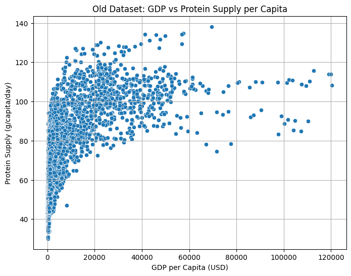

```python
# Plot for OLD dataset
plt.figure(figsize=(8,6))
sns.scatterplot(data=final_merged_old, x='gdp', y='pcpdprotein')
plt.title('Old Dataset: GDP vs Protein Supply per Capita')
plt.xlabel('GDP per Capita (USD)')
plt.ylabel('Protein Supply (g/capita/day)')
plt.grid(True)
plt.show()
```

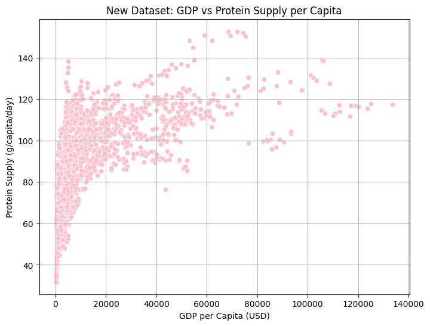

```python
# Plot for NEW dataset
plt.figure(figsize=(8,6))
sns.scatterplot(data=final_merged_new, x='gdp', y='pcpdprotein', color='pink')
plt.title('New Dataset: GDP vs Protein Supply per Capita')
plt.xlabel('GDP per Capita (USD)')
plt.ylabel('Protein Supply (g/capita/day)')
plt.grid(True)
plt.show()
```

# Scatterplot Analysis: GDP per Capita vs Protein Supply

## Old Dataset:

The scatterplot for the old merged dataset shows the relationship between GDP per capita and per capita protein supply across countries.

- There is a **positive relationship** between GDP and protein supply.
- Countries with **higher GDP per capita** tend to have **higher protein availability**.
- However, the data points are **more scattered**, especially among countries with lower income levels.
- This suggests that in the old dataset, economic wealth was an important factor for dietary quality, but not the only one.

## New Dataset:

The scatterplot for the new merged dataset also shows the relationship between GDP per capita and protein supply.

- The **positive correlation** between GDP and protein supply remains strong.
- Compared to the old dataset, the **new data is slightly tighter** — indicating a **stronger, cleaner relationship**.
- Higher GDP countries consistently show **higher protein consumption**, reflecting better food access and nutritional quality.

# Conclusion:

- **Both datasets** confirm that as countries become wealthier, their populations tend to have **greater access to protein-rich diets**.
- The **new dataset** provides a **more consistent and clearer relationship**, possibly due to improved data quality and coverage.
- Overall, the scatterplots reinforce the link between **economic development and improved nutrition**.

C) IDENTIFICATION OF OUTLIERS AND REPLOTTING OF GRAPHS

```python
# Firstly defining a simple function to remove outliers
def remove_outliers(df, column):
    Q1 = df[column].quantile(0.25)
    Q3 = df[column].quantile(0.75)
    IQR = Q3 - Q1
    lower_bound = Q1 - 1.5 * IQR
    upper_bound = Q3 + 1.5 * IQR
    return df[(df[column] >= lower_bound) & (df[column] <= upper_bound)]

# Step 1: Remove outliers for GDP and Protein separately
# For OLD dataset
final_merged_old_clean = remove_outliers(final_merged_old, 'gdp')
final_merged_old_clean = remove_outliers(final_merged_old_clean, 'pcpdprotein')

# For NEW dataset
final_merged_new_clean = remove_outliers(final_merged_new, 'gdp')
final_merged_new_clean = remove_outliers(final_merged_new_clean, 'pcpdprotein')
```

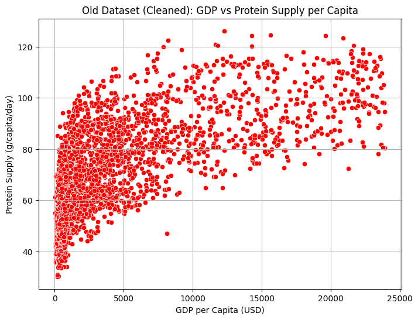

```python
# Step 2: Re-plot scatterplots without outliers

# Plot OLD dataset (without outliers)
plt.figure(figsize=(8,6))
sns.scatterplot(data=final_merged_old_clean, x='gdp', y='pcpdprotein', color='red')
plt.title('Old Dataset (Cleaned): GDP vs Protein Supply per Capita')
plt.xlabel('GDP per Capita (USD)')
plt.ylabel('Protein Supply (g/capita/day)')
plt.grid(True)
plt.show()
```

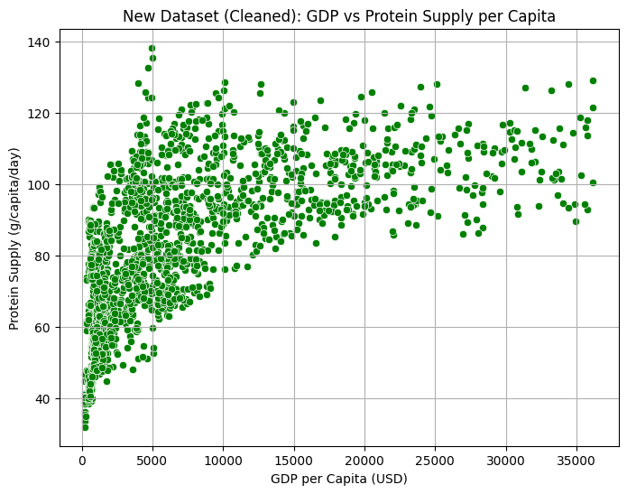

```python
# Plot NEW dataset (without outliers)
plt.figure(figsize=(8,6))
sns.scatterplot(data=final_merged_new_clean, x='gdp', y='pcpdprotein', color='green')
plt.title('New Dataset (Cleaned): GDP vs Protein Supply per Capita')
plt.xlabel('GDP per Capita (USD)')
plt.ylabel('Protein Supply (g/capita/day)')
plt.grid(True)
plt.show()
```

# Scatterplot Analysis after Outlier Removal (Old and New Datasets)

## Old Dataset:

- Outliers based on GDP and protein supply were removed using the IQR method.
- The cleaned scatterplot shows a **clearer positive relationship** between GDP per capita and protein supply.
- Higher GDP countries consistently show **higher protein intake**, with less noise compared to before.

# Conclusion:

- Removing outliers improved the visibility of the underlying trend.
- Both datasets confirm that **wealthier countries have better protein availability**, but the new dataset shows it more clearly.

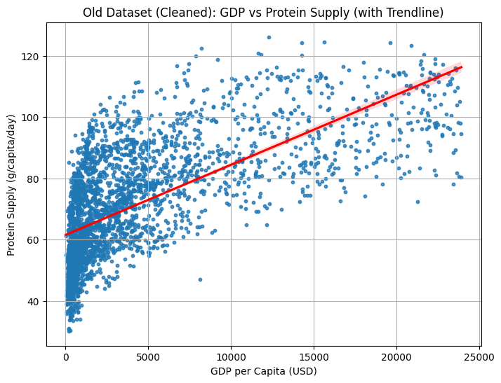

```python
# OLD dataset with regression line
plt.figure(figsize=(8,6))
sns.regplot(data=final_merged_old_clean, x='gdp', y='pcpdprotein', scatter_kws={"s": 10}, line_kws={"color": "red"})
plt.title('Old Dataset (Cleaned): GDP vs Protein Supply (with Trendline)')
plt.xlabel('GDP per Capita (USD)')
plt.ylabel('Protein Supply (g/capita/day)')
plt.grid(True)
plt.show()
```

Red trendlines show the positive correlation clearly.

Slope indicates that as GDP increases, so does protein consumption.

New dataset has a stronger, cleaner trend.

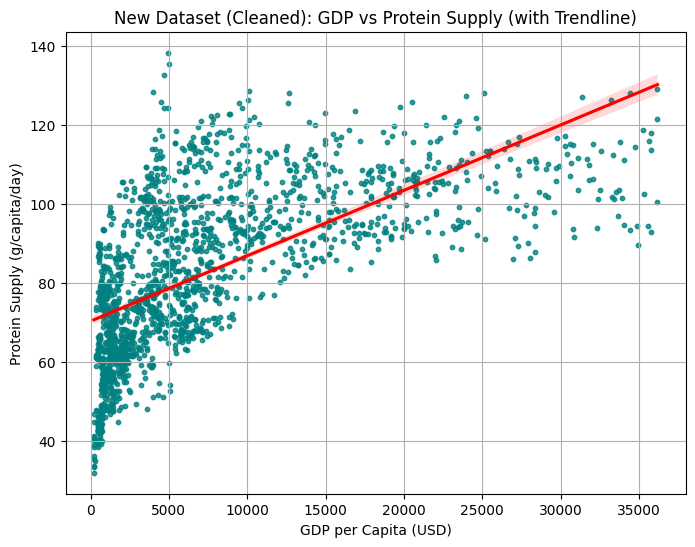

```python
# NEW dataset with regression line
plt.figure(figsize=(8,6))
sns.regplot(data=final_merged_new_clean, x='gdp', y='pcpdprotein', color='teal', scatter_kws={"s": 10}, line_kws={"color": "red"})
plt.title('New Dataset (Cleaned): GDP vs Protein Supply (with Trendline)')
plt.xlabel('GDP per Capita (USD)')
plt.ylabel('Protein Supply (g/capita/day)')
plt.grid(True)
plt.show()
```

```python
# saving datasets as csv files
gdp_merged.to_csv('gdp_merged.csv', index=False)
final_merged_old.to_csv('final_merged_old.csv', index=False)
final_merged_new.to_csv('final_merged_new.csv', index=False)
```